# Exploration

- Introduction
- Columns Descriptions
- Data Preparation
- Data Analysis
  - Checking Missing Values
  - Distribution of the features
  - Correlation Matrix

## Columns Descriptions

- **id**: unique identifier. **integer**.
- **age**: truncated to full years. **Integer**.
- **sex**: "F" or "M". will be changed to "F"=0 , "M"=1. **Binary**.
- **is_smoking**: "YES" if currently a smoker, "NO" otherwise. changed to "YES"=1, "NO"=0. **Binary**.
- **cigsPerDay**: Number of cigaretts patient usually smokes per a day. **Continues** (half a cigaret can count as well).
- **BPMeds**: whether or not the patient was on blood pressure medication. **Binary**.
- **prevalentStroke**: whether or not the patient had previously had a stroke. **Binary**.
- **prevalentHyp**: whether or not the patient was hypertensive. **Binary**.
- **diabetes**: whether or not the patient had diabetes. **Binary**.
- **totChol**: total cholesterol level. **Continuous**.
- **sysBP**: systolic blood pressure. **Continuous**.
- **diaBP**: diastolic blood pressure. **Continuous**.
- **BMI**: Body Mass Index. **Continuous**.
- **heartRate**: heart rate. **Continuous** (In medical research, variables such as heart rate though in fact discrete, yet are considered continuous because of large number of possible values).
- **glucose**: glucose level. **Continuous**.
- **education**: although not explained in kaggle, we notice that it has 4 categories. disscusion online suggests: 1="didn't graduate high school", 2="graduated high school / GED", 3="attend collage/university without graduating", 4=" graduated from collage/university". **Categorical**.

### Target Variable: **TenYearCHD**

#### 1 if the patient had a coronary heart disease CHD in the next 10 years since

#### giving the sample. If not then 0. **Binary**.

## Data Preparation

```python
import pandas as pd
import numpy as np
import matplotlib.pyplot as plt
import seaborn as sns
import warnings
warnings.filterwarnings('ignore')
from framingham_score import *
from sklearn.impute import KNNImputer
```

```python
def preprocess_data(df, handle_missings='median'):
    categorical_columns = ['is_smoking', "BPMeds", 'prevalentStroke', 'prevalentHyp', 'diabetes', 'sex', 'education']
    df.loc[df['is_smoking'] == "YES", 'is_smoking'] = 1
    df.loc[df['is_smoking'] == "NO", 'is_smoking'] = 0
    df.loc[df['sex'] == "M", 'sex'] = 1
    df.loc[df['sex'] == "F", 'sex'] = 0
    df["is_smoking"] = df["is_smoking"].astype(int)
    df["sex"] = df["sex"].astype(int)

    if handle_missings == 'median':
        for col in df.columns:
            if col not in categorical_columns:
                mean_col = df[col].median()
                df[col] = df[col].fillna(mean_col)
            else:
                mean_col = np.argmax(df[col])
                df[col] = df[col].fillna(mean_col)
    elif handle_missings == 'knn':
        for col in df.columns:
            if col not in categorical_columns:
                mean_col = df[col].median()
                df[col] = df[col].fillna(mean_col)

        imputator = KNNImputer(n_neighbors=5)
        df = pd.DataFrame(imputator.fit_transform(df), columns=df.columns)

    # Column to see if patient was in Hypertension during the sampling.
    df.insert(len(df.columns) - 1, 'isHyp', value=0)
    df.loc[(df['sysBP'] >= 130) | (df['diaBP'] >= 80), 'isHyp'] = 1

    # creating categorical column for packs of cigarettes.
    df.insert(len(df.columns) - 1, 'packsOfCigs', value=0)
    df.loc[df['cigsPerDay'] > 0, 'packsOfCigs'] = 1
    df.loc[df['cigsPerDay'] >= 10, 'packsOfCigs'] = 2
    df.loc[df['cigsPerDay'] >= 20, 'packsOfCigs'] = 3
    df.loc[df['cigsPerDay'] >= 30, 'packsOfCigs'] = 4

    # creating categorical column for glucose levels.
    df.insert(len(df.columns) - 1, 'glucose_level', value=0)
    df.loc[df['glucose'] > 2.6 * 18, 'glucose_level'] = 1
    df.loc[df['glucose'] > 4.7 * 18, 'glucose_level'] = 2
    df.loc[df['glucose'] > 6.3 * 18, 'glucose_level'] = 3
    df.loc[df['glucose'] > 8.5 * 18, 'glucose_level'] = 4

    # Score2 diabetes score (Framingham Risk Score)
    df.insert(len(df.columns) - 1, 'diabetes_score2', value=0)
    df['diabetes_score2'] = df.apply(lambda x: calculate_framingham_score(
        x['age'], x['sex'], x['is_smoking'], x['cigsPerDay'], x['BPMeds'], x['prevalentStroke'], x['prevalentHyp'],
        x['diabetes'],
        x['totChol'], x['sysBP'], x['diaBP'], x['BMI'], x['heartRate'], x['glucose'], x['education']), axis=1)
    return df


def remove_outliers_iqr(df, columns, threshold=1.5):
    # Calculate the IQR for each column
    Q1 = df[columns].quantile(0.25)
    Q3 = df[columns].quantile(0.75)
    IQR = Q3 - Q1

    # Define lower and upper bounds to identify outliers
    lower_bound = Q1 - threshold * IQR
    upper_bound = Q3 + threshold * IQR

    # Filter rows without outliers
    mask = ~((df[columns] < lower_bound) | (df[columns] > upper_bound)).any(axis=1)
    return df[mask]


# Load Data
data_dir = r"C:\Users\soldier109\PycharmProjects\Moshal Medicine Hackaton 2023\Datasets\Cardiovascular Study Dataset"
trainset = preprocess_data(pd.read_csv(data_dir+"/train.csv"), handle_missings=None)
testset = preprocess_data(pd.read_csv(data_dir+"/test.csv"), handle_missings=None)
```

## Data Analysis

```python
trainset.dtypes
```

```
id                   int64
age                  int64
education          float64
sex                  int32
is_smoking           int32
cigsPerDay         float64
BPMeds             float64
prevalentStroke      int64
prevalentHyp         int64
diabetes             int64
totChol            float64
sysBP              float64
diaBP              float64
BMI                float64
heartRate          float64
glucose            float64
isHyp                int64
packsOfCigs          int64
glucose_level        int64
diabetes_score2    float64
TenYearCHD           int64
dtype: object
```

```python
print(trainset.shape)
print(testset.shape)
print(f"Ration between train and test: {round(len(testset) / len(trainset), 4)}")
```

```
(3390, 21)
(848, 20)
Ration between train and test: 0.2501
```

```python
trainset.describe(include='all').T
```

|  | count | mean | std | min | 25% | 50% | 75% | max |
| --- | --- | --- | --- | --- | --- | --- | --- | --- |
| id | 3390.0 | 1694.500000 | 978.753033 | 0.000000 | 847.25000 | 1694.50000 | 2541.750000 | 3389.0 |
| age | 3390.0 | 49.542183 | 8.592878 | 32.000000 | 42.00000 | 49.00000 | 56.000000 | 70.0 |
| education | 3303.0 | 1.970936 | 1.019081 | 1.000000 | 1.00000 | 2.00000 | 3.000000 | 4.0 |
| sex | 3390.0 | 0.432743 | 0.495529 | 0.000000 | 0.00000 | 0.00000 | 1.000000 | 1.0 |
| is_smoking | 3390.0 | 0.497640 | 0.500068 | 0.000000 | 0.00000 | 0.00000 | 1.000000 | 1.0 |
| cigsPerDay | 3368.0 | 9.069477 | 11.879078 | 0.000000 | 0.00000 | 0.00000 | 20.000000 | 70.0 |
| BPMeds | 3346.0 | 0.029886 | 0.170299 | 0.000000 | 0.00000 | 0.00000 | 0.000000 | 1.0 |
| prevalentStroke | 3390.0 | 0.006490 | 0.080309 | 0.000000 | 0.00000 | 0.00000 | 0.000000 | 1.0 |
| prevalentHyp | 3390.0 | 0.315339 | 0.464719 | 0.000000 | 0.00000 | 0.00000 | 1.000000 | 1.0 |
| diabetes | 3390.0 | 0.025664 | 0.158153 | 0.000000 | 0.00000 | 0.00000 | 0.000000 | 1.0 |
| totChol | 3352.0 | 237.074284 | 45.247430 | 107.000000 | 206.00000 | 234.00000 | 264.000000 | 696.0 |
| sysBP | 3390.0 | 132.601180 | 22.292030 | 83.500000 | 117.00000 | 128.50000 | 144.000000 | 295.0 |
| diaBP | 3390.0 | 82.883038 | 12.023581 | 48.000000 | 74.50000 | 82.00000 | 90.000000 | 142.5 |
| BMI | 3376.0 | 25.794964 | 4.115449 | 15.960000 | 23.02000 | 25.38000 | 28.040000 | 56.8 |
| heartRate | 3389.0 | 75.977279 | 11.971868 | 45.000000 | 68.00000 | 75.00000 | 83.000000 | 143.0 |
| glucose | 3086.0 | 82.086520 | 24.244753 | 40.000000 | 71.00000 | 78.00000 | 87.000000 | 394.0 |
| isHyp | 3390.0 | 0.662537 | 0.472914 | 0.000000 | 0.00000 | 1.00000 | 1.000000 | 1.0 |
| packsOfCigs | 3390.0 | 1.246313 | 1.465581 | 0.000000 | 0.00000 | 0.00000 | 3.000000 | 4.0 |
| glucose_level | 3390.0 | 1.236873 | 0.699616 | 0.000000 | 1.00000 | 1.00000 | 2.000000 | 4.0 |
| diabetes_score2 | 2944.0 | -54.164484 | 319.260261 | -6837.979226 | -5.00817 | 0.92285 | 0.999844 | 1.0 |
| TenYearCHD | 3390.0 | 0.150737 | 0.357846 | 0.000000 | 0.00000 | 0.00000 | 0.000000 | 1.0 |

```python
# Checking for duplicated rows
trainset[trainset.duplicated()]
```

|  | id | age | education | sex | is_smoking | cigsPerDay | BPMeds | prevalentStroke | prevalentHyp | diabetes | ... | sysBP | diaBP | BMI | heartRate | glucose | isHyp | packsOfCigs | glucose_level | diabetes_score2 | TenYearCHD |
| --- | --- | --- | --- | --- | --- | --- | --- | --- | --- | --- | --- | --- | --- | --- | --- | --- | --- | --- | --- | --- | --- |

0 rows × 21 columns

No duplicate rows were found.

### Checking missing values

```python
missing_matrix = [list(trainset.isnull().sum()), list(testset.isnull().sum()) + [0]]
missing_matrix = pd.DataFrame(missing_matrix, columns=trainset.columns, index=['trainset', 'testset']).T.reset_index()
missing_matrix
```

|  | index | trainset | testset |
| --- | --- | --- | --- |
| 0 | id | 0 | 0 |
| 1 | age | 0 | 0 |
| 2 | education | 87 | 18 |
| 3 | sex | 0 | 0 |
| 4 | is_smoking | 0 | 0 |
| 5 | cigsPerDay | 22 | 7 |
| 6 | BPMeds | 44 | 9 |
| 7 | prevalentStroke | 0 | 0 |
| 8 | prevalentHyp | 0 | 0 |
| 9 | diabetes | 0 | 0 |
| 10 | totChol | 38 | 12 |
| 11 | sysBP | 0 | 0 |
| 12 | diaBP | 0 | 0 |
| 13 | BMI | 14 | 5 |
| 14 | heartRate | 1 | 0 |
| 15 | glucose | 304 | 0 |
| 16 | isHyp | 0 | 0 |
| 17 | packsOfCigs | 0 | 0 |
| 18 | glucose_level | 0 | 114 |
| 19 | diabetes_score2 | 446 | 84 |
| 20 | TenYearCHD | 0 | 0 |

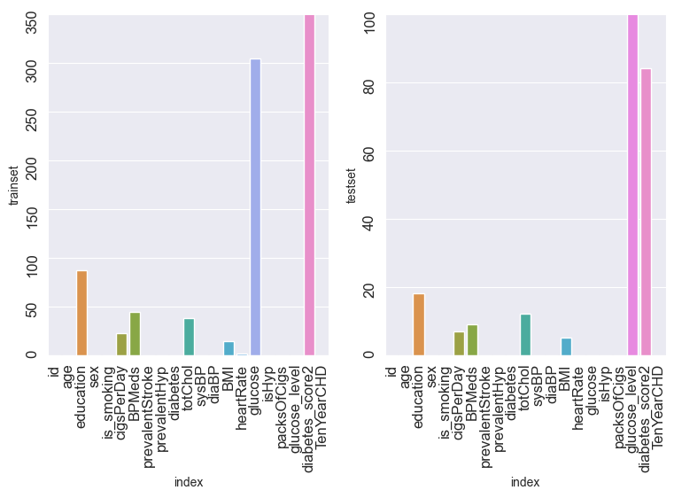

```python
missing_matrix = [list(trainset.isnull().sum()), list(testset.isnull().sum()) + [0]]
missing_matrix = pd.DataFrame(missing_matrix, columns=trainset.columns, index=['trainset', 'testset']).T.reset_index()
figure, axes = plt.subplots(1, 2, sharex=True, figsize=(9, 5))
sns.barplot(ax=axes[0], data=missing_matrix, x=missing_matrix['index'], y='trainset')
sns.barplot(ax=axes[1], data=missing_matrix, x=missing_matrix['index'], y='testset')
axes[0].tick_params(labelsize=12, labelrotation=90)
axes[1].tick_params(labelsize=12, labelrotation=90)
axes[0].set_ylim(0, 350)
axes[1].set_ylim(0, 100)
plt.show()
```

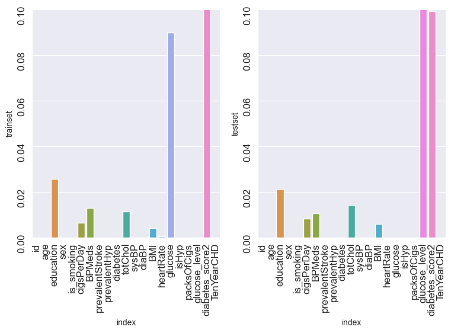

```python
missing_matrix = [list(trainset.isnull().sum()), list(testset.isnull().sum()) + [0]]
missing_matrix = pd.DataFrame(missing_matrix, columns=trainset.columns, index=['trainset', 'testset']).T.reset_index()
missing_matrix['trainset'] = missing_matrix['trainset'] / len(trainset)
missing_matrix['testset'] = missing_matrix['testset'] / len(testset)
figure, axes = plt.subplots(1, 2, sharex=True, figsize=(9, 5))
sns.barplot(ax=axes[0], data=missing_matrix, x=missing_matrix['index'], y='trainset')
sns.barplot(ax=axes[1], data=missing_matrix, x=missing_matrix['index'], y='testset')
axes[0].tick_params(labelsize=12, labelrotation=90)
axes[1].tick_params(labelsize=12, labelrotation=90)
axes[0].set_ylim(0, 0.1)
axes[1].set_ylim(0, 0.1)
plt.show()
```

### Distribution of the features

```python
trainset.describe()
```

|  | id | age | education | sex | is_smoking | cigsPerDay | BPMeds | prevalentStroke | prevalentHyp | diabetes | ... | sysBP | diaBP | BMI | heartRate | glucose | isHyp | packsOfCigs | glucose_level | diabetes_score2 | TenYearCHD |
| --- | --- | --- | --- | --- | --- | --- | --- | --- | --- | --- | --- | --- | --- | --- | --- | --- | --- | --- | --- | --- | --- |
| count | 3390.000000 | 3390.000000 | 3303.000000 | 3390.000000 | 3390.000000 | 3368.000000 | 3346.000000 | 3390.000000 | 3390.000000 | 3390.000000 | ... | 3390.00000 | 3390.000000 | 3376.000000 | 3389.000000 | 3086.000000 | 3390.000000 | 3390.000000 | 3390.000000 | 2944.000000 | 3390.000000 |
| mean | 1694.500000 | 49.542183 | 1.970936 | 0.432743 | 0.497640 | 9.069477 | 0.029886 | 0.006490 | 0.315339 | 0.025664 | ... | 132.60118 | 82.883038 | 25.794964 | 75.977279 | 82.086520 | 0.662537 | 1.246313 | 1.236873 | -54.164484 | 0.150737 |
| std | 978.753033 | 8.592878 | 1.019081 | 0.495529 | 0.500068 | 11.879078 | 0.170299 | 0.080309 | 0.464719 | 0.158153 | ... | 22.29203 | 12.023581 | 4.115449 | 11.971868 | 24.244753 | 0.472914 | 1.465581 | 0.699616 | 319.260261 | 0.357846 |
| min | 0.000000 | 32.000000 | 1.000000 | 0.000000 | 0.000000 | 0.000000 | 0.000000 | 0.000000 | 0.000000 | 0.000000 | ... | 83.50000 | 48.000000 | 15.960000 | 45.000000 | 40.000000 | 0.000000 | 0.000000 | 0.000000 | -6837.979226 | 0.000000 |
| 25% | 847.250000 | 42.000000 | 1.000000 | 0.000000 | 0.000000 | 0.000000 | 0.000000 | 0.000000 | 0.000000 | 0.000000 | ... | 117.00000 | 74.500000 | 23.020000 | 68.000000 | 71.000000 | 0.000000 | 0.000000 | 1.000000 | -5.008170 | 0.000000 |
| 50% | 1694.500000 | 49.000000 | 2.000000 | 0.000000 | 0.000000 | 0.000000 | 0.000000 | 0.000000 | 0.000000 | 0.000000 | ... | 128.50000 | 82.000000 | 25.380000 | 75.000000 | 78.000000 | 1.000000 | 0.000000 | 1.000000 | 0.922850 | 0.000000 |
| 75% | 2541.750000 | 56.000000 | 3.000000 | 1.000000 | 1.000000 | 20.000000 | 0.000000 | 0.000000 | 1.000000 | 0.000000 | ... | 144.00000 | 90.000000 | 28.040000 | 83.000000 | 87.000000 | 1.000000 | 3.000000 | 2.000000 | 0.999844 | 0.000000 |
| max | 3389.000000 | 70.000000 | 4.000000 | 1.000000 | 1.000000 | 70.000000 | 1.000000 | 1.000000 | 1.000000 | 1.000000 | ... | 295.00000 | 142.500000 | 56.800000 | 143.000000 | 394.000000 | 1.000000 | 4.000000 | 4.000000 | 1.000000 | 1.000000 |

8 rows × 21 columns

#### Age

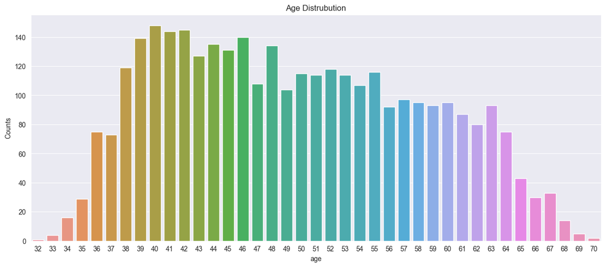

```python
fig, ax = plt.subplots(figsize=(15, 6))
var_dis = pd.DataFrame(trainset.groupby(['age'])['id'].count())
sns.barplot(x=var_dis.index, y=var_dis['id'])
plt.ylabel('Counts')
plt.title('Age Distrubution')
```

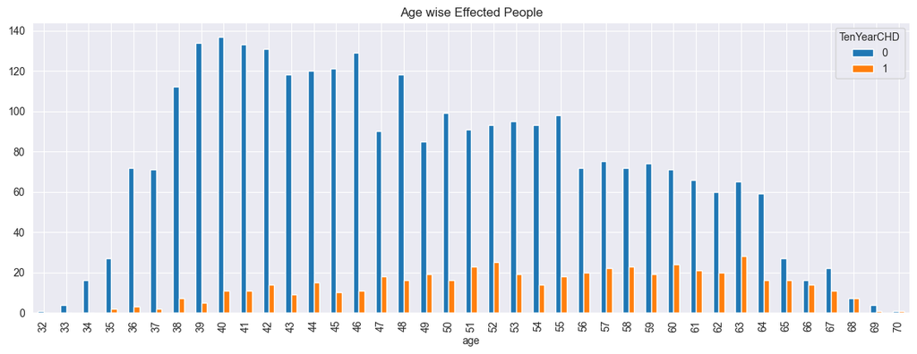

```python
plt.rcParams['figure.figsize'] = (15, 5)
trainset.groupby(['age', 'TenYearCHD'])['id'].count().unstack().plot(kind='bar')
plt.title('Age wise Effected People')
```

We can see that the ratio between those classified 0 and those classified as 1 on the column TenYearCHD keeps getting smaller as the age grows, so we can assume that the risk of TenYearCHD is higher when the patient get older.

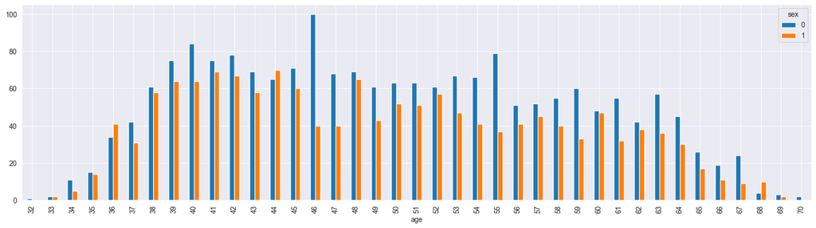

```python
plt.rcParams['figure.figsize'] = (20, 5)
trainset.groupby(['age', 'sex'])['TenYearCHD'].count().unstack().plot(kind='bar')
```

#### Education

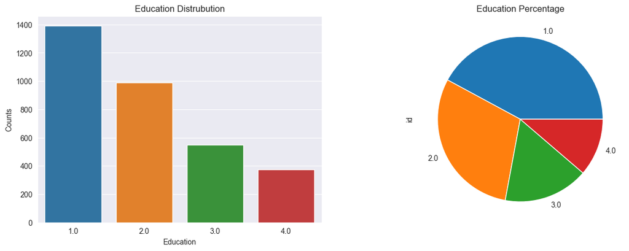

```python
fig, ax = plt.subplots(1, 2, figsize=(15, 5))
ax1 = plt.subplot(1, 2, 1)
var_dis = pd.DataFrame(trainset.groupby(['education'])['id'].count())
sns.barplot(x=var_dis.index, y=var_dis['id'])
plt.xlabel('Education')
plt.ylabel('Counts')
plt.title('Education Distrubution')
ax2 = plt.subplot(1, 2, 2)
trainset.groupby(['education'])['id'].count().plot(kind='pie')
plt.title('Education Percentage')
```

We can see that as expected, as the education level go up, it's category contain less samples.

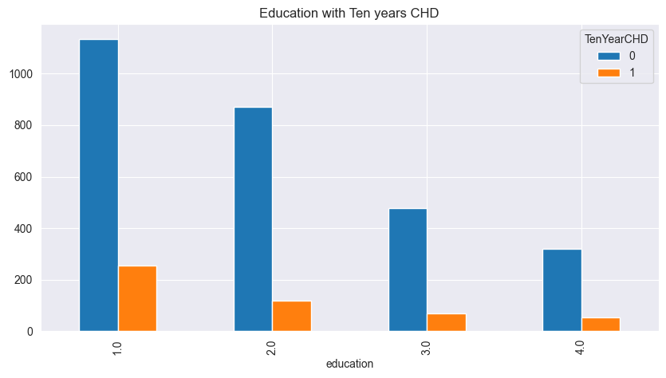

```python
plt.rcParams['figure.figsize'] = (10, 5)
trainset.groupby(['education', 'TenYearCHD'])['id'].count().unstack().plot(kind='bar')
plt.title('Education with Ten years CHD')
```

```python
trainset.groupby(['education'])['TenYearCHD'].mean()
```

```
education
1.0    0.184040
2.0    0.119192
3.0    0.127505
4.0    0.144772
Name: TenYearCHD, dtype: float64
```

#### Sex

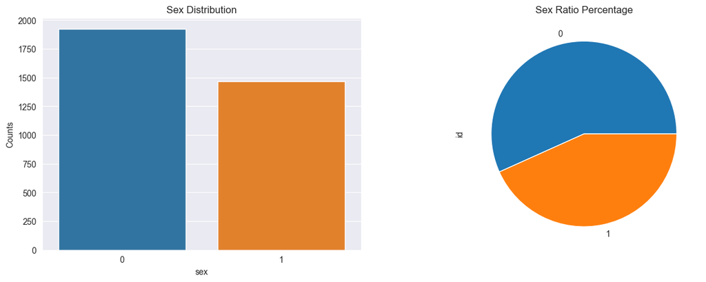

```python
fig, ax = plt.subplots(1, 2, figsize=(15, 5))
ax1 = plt.subplot(1, 2, 1)
var_dis = pd.DataFrame(trainset.groupby(['sex'])['id'].count())
sns.barplot(x=var_dis.index, y=var_dis['id'])
plt.xlabel('sex')
plt.ylabel('Counts')
plt.title('Sex Distribution')
ax2 = plt.subplot(1, 2, 2)
trainset.groupby(['sex'])['id'].count().plot(kind='pie')
plt.title('Sex Ratio Percentage')
```

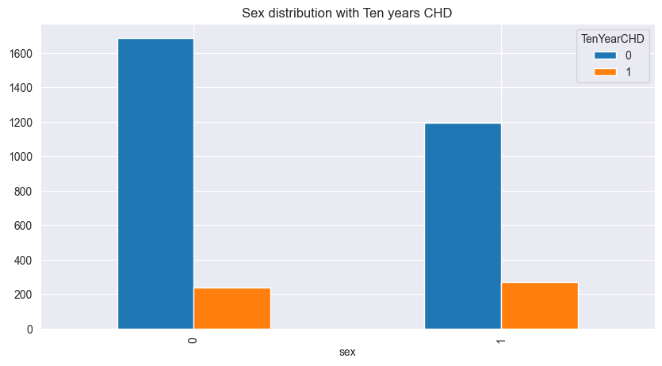

```python
plt.rcParams['figure.figsize'] = (10, 5)
trainset.groupby(['sex', 'TenYearCHD'])['id'].count().unstack().plot(kind='bar')
plt.title('Sex distribution with Ten years CHD')
```

```python
trainset.groupby(['sex'])['TenYearCHD'].mean()
```

```
sex
0    0.124285
1    0.185412
Name: TenYearCHD, dtype: float64
```

We can see that male have higher ratio of risk TenYearCHD.

#### Is Smoking

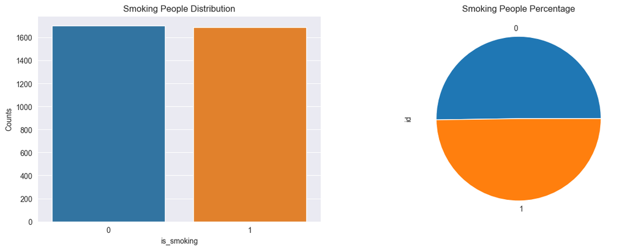

```python
fig, ax = plt.subplots(1, 2, figsize=(15, 5))
ax1 = plt.subplot(1, 2, 1)
var_dis = pd.DataFrame(trainset.groupby(['is_smoking'])['id'].count())
sns.barplot(x=var_dis.index, y=var_dis['id'])
plt.xlabel('is_smoking')
plt.ylabel('Counts')
plt.title('Smoking People Distribution')
ax2 = plt.subplot(1, 2, 2)
trainset.groupby(['is_smoking'])['id'].count().plot(kind='pie')
plt.title('Smoking People Percentage')
```

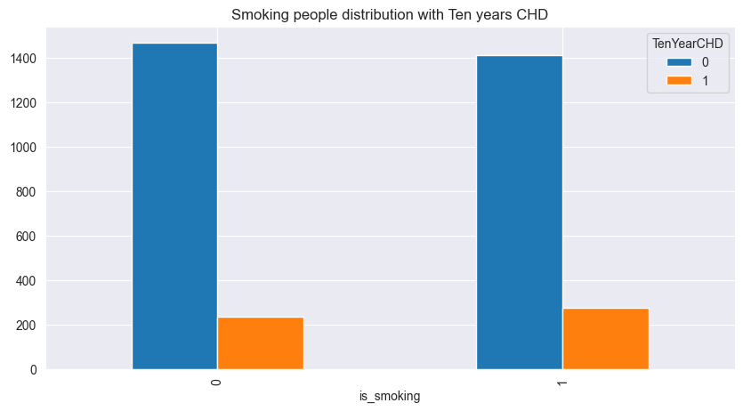

```python
plt.rcParams['figure.figsize'] = (10, 5)
trainset.groupby(['is_smoking', 'TenYearCHD'])['id'].count().unstack().plot(kind='bar')
plt.title('Smoking people distribution with Ten years CHD')
```

```python
trainset.groupby(['is_smoking'])['TenYearCHD'].mean()
```

```
is_smoking
0    0.138579
1    0.163011
Name: TenYearCHD, dtype: float64
```

We can see that smokers have higher ratio of risk TenYearCHD.

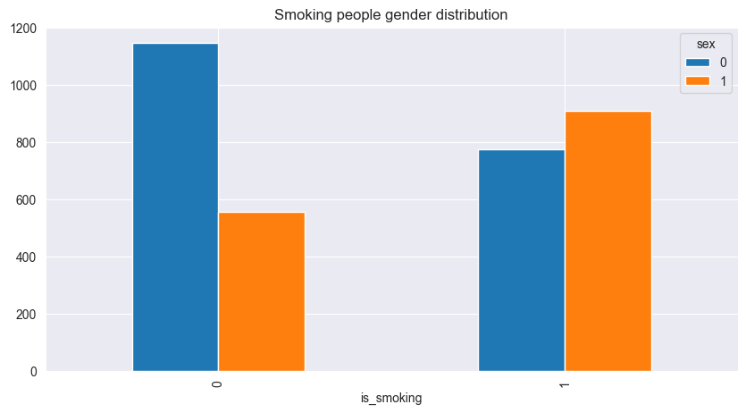

```python
plt.rcParams['figure.figsize'] = (10, 5)
trainset.groupby(['is_smoking', 'sex'])['id'].count().unstack().plot(kind='bar')
plt.title('Smoking people gender distribution')
```

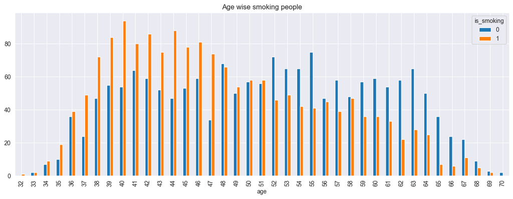

```python
plt.rcParams['figure.figsize'] = (15, 5)
trainset.groupby(['age', 'is_smoking'])['id'].count().unstack().plot(kind='bar')
plt.title('Age wise smoking people')
```

#### Cigarettes Per Day

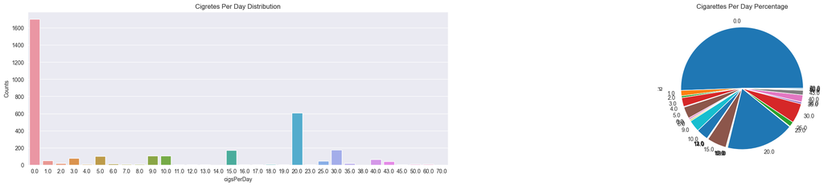

```python
fig, ax = plt.subplots(1, 2, figsize=(30, 5))
ax1 = plt.subplot(1, 2, 1)
var_dis = pd.DataFrame(trainset.groupby(['cigsPerDay'])['id'].count())
sns.barplot(x=var_dis.index, y=var_dis['id'])
plt.xlabel('cigsPerDay')
plt.ylabel('Counts')
plt.title('Cigretes Per Day Distribution')
ax2 = plt.subplot(1, 2, 2)
trainset.groupby(['cigsPerDay'])['id'].count().plot(kind='pie')
plt.title('Cigarettes Per Day Percentage')
```

We can see that approximately 50% of the patients are not smoking at all, and we got many people that smoke pack cigarettes per day.

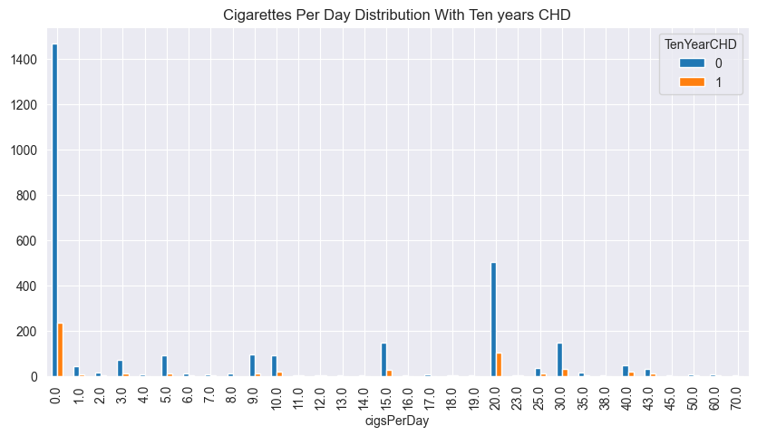

```python
plt.rcParams['figure.figsize'] = (10, 5)
trainset.groupby(['cigsPerDay', 'TenYearCHD'])['id'].count().unstack().plot(kind='bar')
plt.title('Cigarettes Per Day Distribution With Ten years CHD')
```

Let's try to categorize this column by half packs of cigarettes.

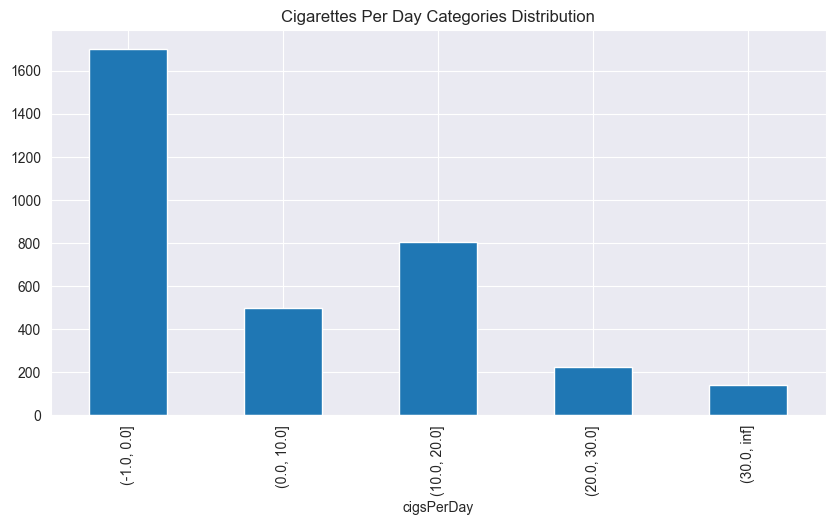

```python
temp = trainset[['id', 'cigsPerDay', 'TenYearCHD']]
temp.groupby(pd.cut(temp['cigsPerDay'], [-1, 0, 10, 20, 30, np.inf]))['id'].count().plot(kind='bar')
plt.title('Cigarettes Per Day Categories Distribution')
```

We shall create a new column representing these categories named "packsOfCigs".

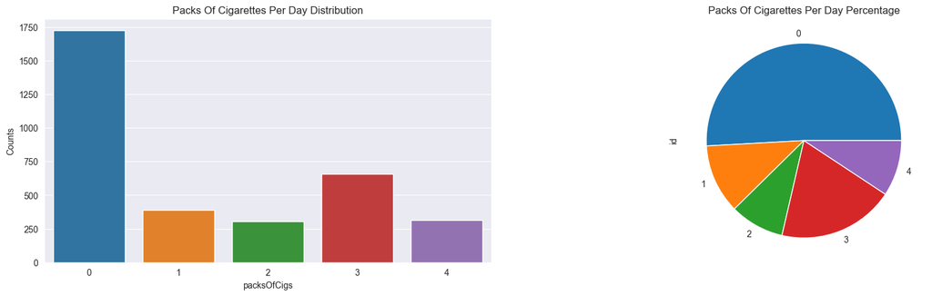

```python
fig, ax = plt.subplots(1, 2, figsize=(20, 5))
ax1 = plt.subplot(1, 2, 1)
var_dis = pd.DataFrame(trainset.groupby(['packsOfCigs'])['id'].count())
sns.barplot(x=var_dis.index, y=var_dis['id'])
plt.xlabel('packsOfCigs')
plt.ylabel('Counts')
plt.title('Packs Of Cigarettes Per Day Distribution')
ax2 = plt.subplot(1, 2, 2)
trainset.groupby(['packsOfCigs'])['id'].count().plot(kind='pie')
plt.title('Packs Of Cigarettes Per Day Percentage')
```

#### BPMed

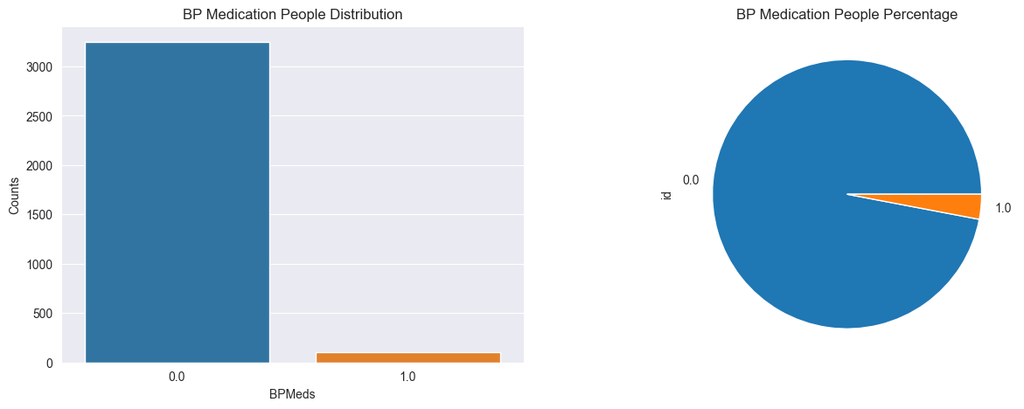

```python
fig, ax = plt.subplots(1, 2, figsize=(15, 5))
ax1 = plt.subplot(1, 2, 1)
var_dis = pd.DataFrame(trainset.groupby(['BPMeds'])['id'].count())
sns.barplot(x=var_dis.index, y=var_dis['id'])
plt.xlabel('BPMeds')
plt.ylabel('Counts')
plt.title('BP Medication People Distribution')
ax2 = plt.subplot(1, 2, 2)
trainset.groupby(['BPMeds'])['id'].count().plot(kind='pie')
plt.title('BP Medication People Percentage')
```

We can see that we have more people that are not on blood pressure medication, so we can suppose that this feature is can be considered to be eliminated.

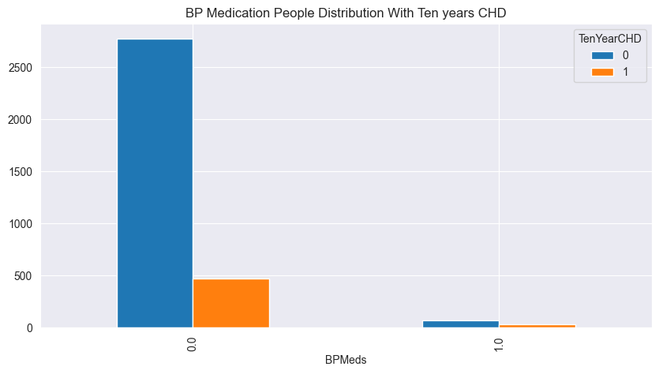

```python
plt.rcParams['figure.figsize'] = (10, 5)
trainset.groupby(['BPMeds', 'TenYearCHD'])['id'].count().unstack().plot(kind='bar')
plt.title('BP Medication People Distribution With Ten years CHD')
```

```python
trainset.groupby(['BPMeds'])['TenYearCHD'].mean()
```

```
BPMeds
0.0    0.145102
1.0    0.330000
Name: TenYearCHD, dtype: float64
```

#### Prevalent Stroke

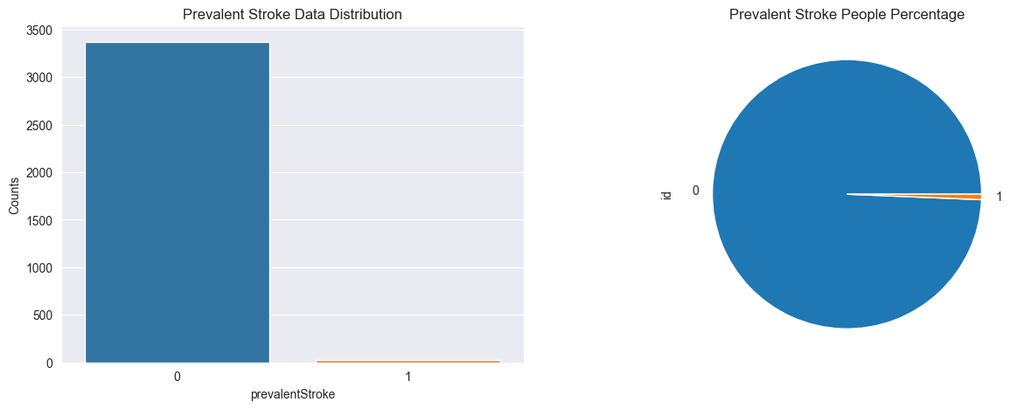

```python
fig, ax = plt.subplots(1, 2, figsize=(15, 5))
ax1 = plt.subplot(1, 2, 1)
var_dis = pd.DataFrame(trainset.groupby(['prevalentStroke'])['id'].count())
sns.barplot(x=var_dis.index, y=var_dis['id'])
plt.xlabel('prevalentStroke')
plt.ylabel('Counts')
plt.title('Prevalent Stroke Data Distribution')
ax2 = plt.subplot(1, 2, 2)
trainset.groupby(['prevalentStroke'])['id'].count().plot(kind='pie')
plt.title('Prevalent Stroke People Percentage')
```

We can see that we have more people that didn't have prevalent stroke, so we can suppose that this feature is can be considered to be eliminated.

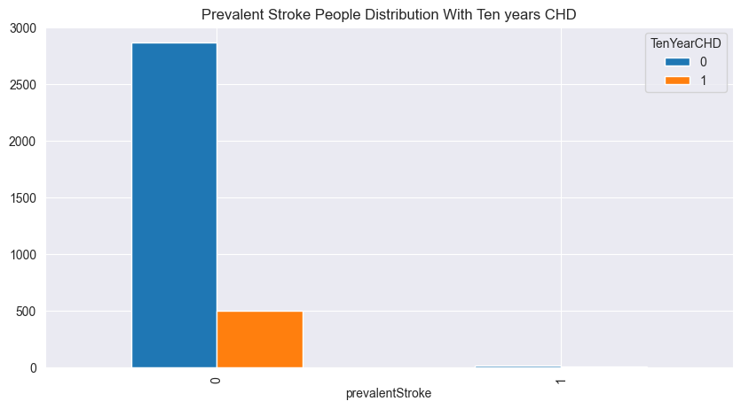

```python
plt.rcParams['figure.figsize'] = (10, 5)
trainset.groupby(['prevalentStroke', 'TenYearCHD'])['id'].count().unstack().plot(kind='bar')
plt.title('Prevalent Stroke People Distribution With Ten years CHD')
```

#### Prevalent Hypertension

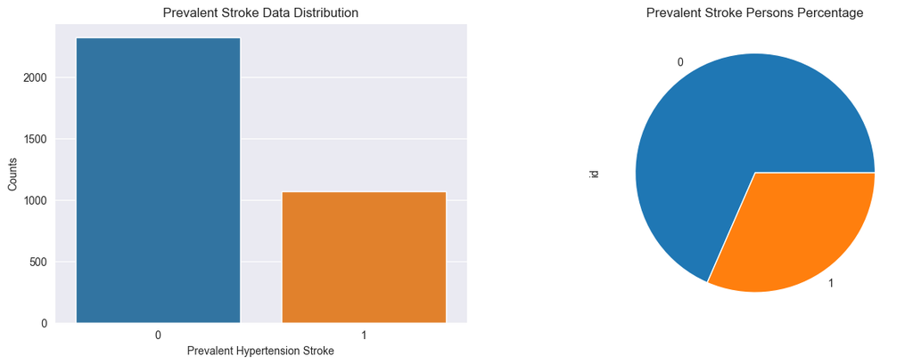

```python
fig, ax = plt.subplots(1, 2, figsize=(15, 5))
ax1 = plt.subplot(1, 2, 1)
var_dis = pd.DataFrame(trainset.groupby(['prevalentHyp'])['id'].count())
sns.barplot(x=var_dis.index, y=var_dis['id'])
plt.xlabel('Prevalent Hypertension Stroke')
plt.ylabel('Counts')
plt.title('Prevalent Stroke Data Distribution')
ax2 = plt.subplot(1, 2, 2)
trainset.groupby(['prevalentHyp'])['id'].count().plot(kind='pie')
plt.title('Prevalent Stroke Persons Percentage')
```

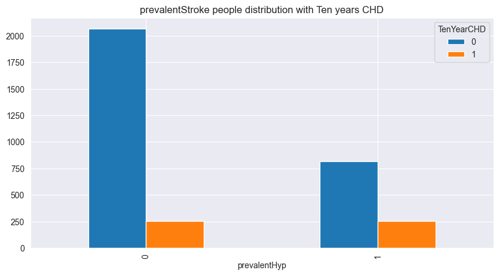

```python
plt.rcParams['figure.figsize'] = (10, 5)
trainset.groupby(['prevalentHyp', 'TenYearCHD'])['id'].count().unstack().plot(kind='bar')
plt.title('prevalentStroke people distribution with Ten years CHD')
```

```python
trainset.groupby(['prevalentHyp'])['TenYearCHD'].mean()
```

```
prevalentHyp
0    0.110297
1    0.238541
Name: TenYearCHD, dtype: float64
```

We can see that people with prevalent hypertension have higher ratio of risk TenYearCHD.

#### Diabetes

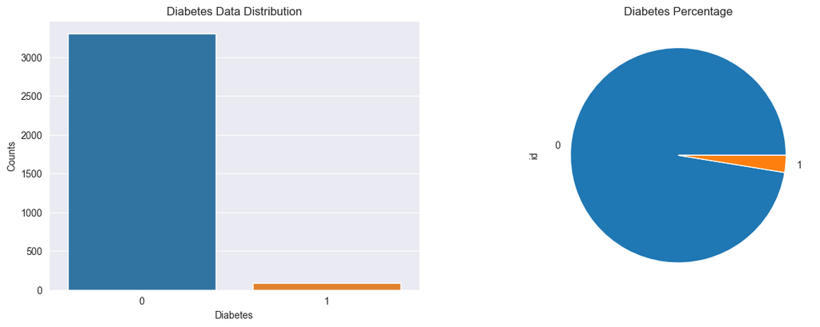

```python
fig, ax = plt.subplots(1, 2, figsize=(15, 5))
ax1 = plt.subplot(1, 2, 1)
var_dis = pd.DataFrame(trainset.groupby(['diabetes'])['id'].count())
sns.barplot(x=var_dis.index, y=var_dis['id'])
plt.xlabel('Diabetes')
plt.ylabel('Counts')
plt.title('Diabetes Data Distribution')
ax2 = plt.subplot(1, 2, 2)
trainset.groupby(['diabetes'])['id'].count().plot(kind='pie')
plt.title('Diabetes Percentage')
```

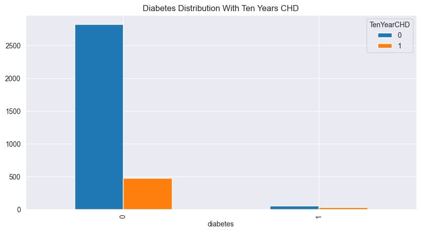

```python
plt.rcParams['figure.figsize'] = (10, 5)
trainset.groupby(['diabetes', 'TenYearCHD'])['id'].count().unstack().plot(kind='bar')
plt.title('Diabetes Distribution With Ten Years CHD')
```

```python
trainset.groupby(['diabetes'])['TenYearCHD'].mean()
```

```
diabetes
0    0.144717
1    0.379310
Name: TenYearCHD, dtype: float64
```

We can see that people with diabetes have higher ratio of risk TenYearCHD, but we got more people that don't have diabetes.

#### Total Cholesterol

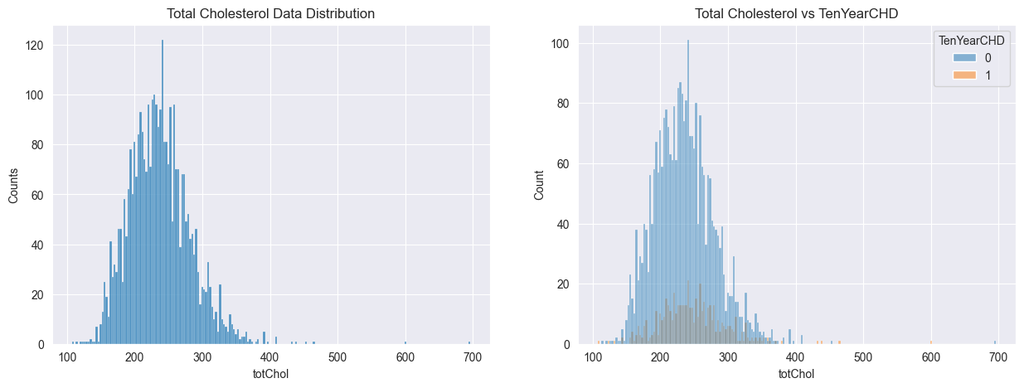

```python
col_name = 'totChol'
fig, ax = plt.subplots(1, 2, figsize=(15, 5))
ax1 = plt.subplot(1, 2, 1)
sns.histplot(trainset, x=col_name, bins=200)
plt.xlabel(col_name)
plt.ylabel('Counts')
plt.title('Total Cholesterol Data Distribution')
ax2 = plt.subplot(1, 2, 2)
sns.histplot(trainset, x=col_name, hue='TenYearCHD', bins=200)
plt.title('Total Cholesterol vs TenYearCHD')
```

```python
high_chol = 240
trainset[trainset['totChol'] >= high_chol]['TenYearCHD'].mean()
```

```
0.18085808580858087
```

We can see that 18% of people who have high cholesterol level have risk of TenYearCHD.

#### Systolic BP

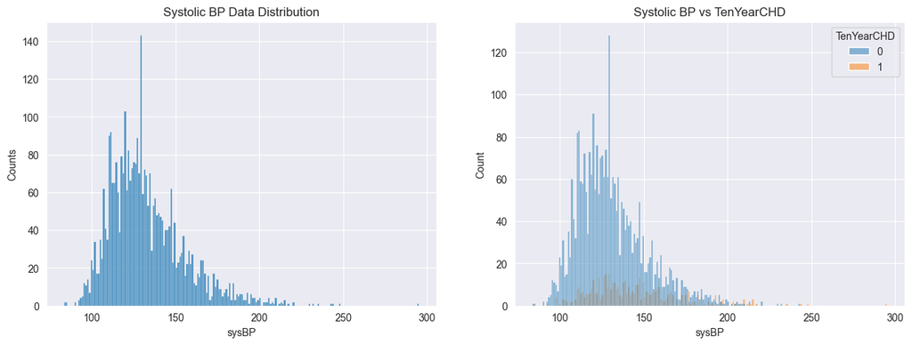

```python
col_name = 'sysBP'
fig, ax = plt.subplots(1, 2, figsize=(15, 5))
ax1 = plt.subplot(1, 2, 1)
sns.histplot(trainset, x=col_name, bins=200)
plt.xlabel(col_name)
plt.ylabel('Counts')
plt.title('Systolic BP Data Distribution')
ax2 = plt.subplot(1, 2, 2)
sns.histplot(trainset, x=col_name, hue='TenYearCHD', bins=200)
plt.title('Systolic BP vs TenYearCHD')
```

We can see that te ratio of risk TenYearCHD is higher when the systolic blood pressure is higher.

#### Diastolic BP

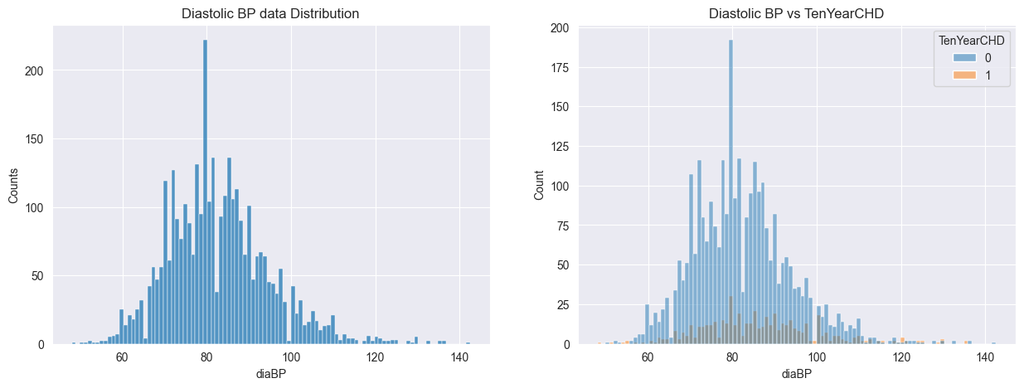

```python
col_name = 'diaBP'
bins = 100
fig, ax = plt.subplots(1, 2, figsize=(15, 5))
ax1 = plt.subplot(1, 2, 1)
sns.histplot(trainset, x=col_name, bins=bins)
plt.xlabel(col_name)
plt.ylabel('Counts')
plt.title('Diastolic BP data Distribution')
ax2 = plt.subplot(1, 2, 2)
sns.histplot(trainset, x=col_name, hue='TenYearCHD', bins=bins)
plt.title('Diastolic BP vs TenYearCHD')
```

#### BMI

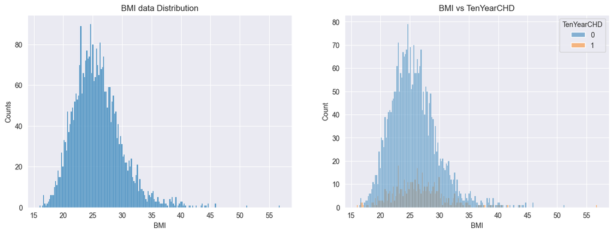

```python
col_name = 'BMI'
bins = 200
fig, ax = plt.subplots(1, 2, figsize=(15, 5))
ax1 = plt.subplot(1, 2, 1)
sns.histplot(trainset, x=col_name, bins=bins)
plt.xlabel(col_name)
plt.ylabel('Counts')
plt.title(f'{col_name} data Distribution')
ax2 = plt.subplot(1, 2, 2)
sns.histplot(trainset, x=col_name, hue='TenYearCHD', bins=bins)
plt.title(f'{col_name} vs TenYearCHD')
```

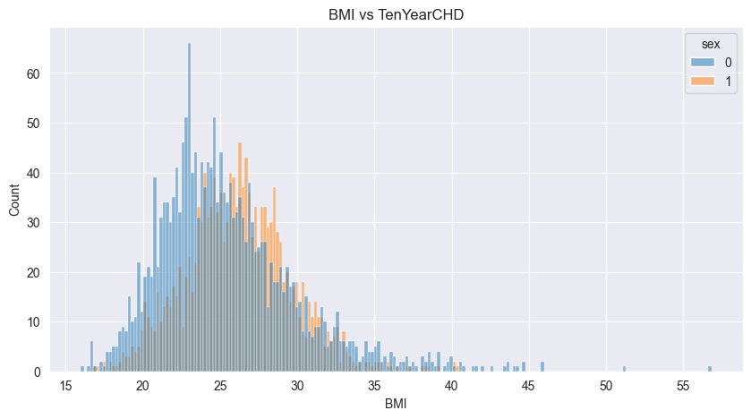

```python
sns.histplot(trainset, x=col_name, hue='sex', bins=bins)
plt.title(f'{col_name} vs TenYearCHD')
```

We can see that male have higher BMI that female which is not surprising.

#### Heart Rate

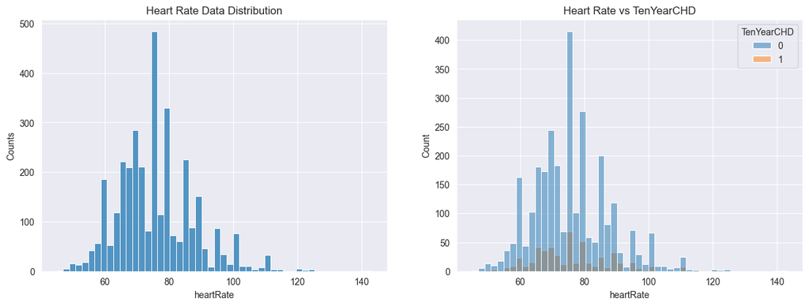

```python
col_name = 'heartRate'
bins = 50
fig, ax = plt.subplots(1, 2, figsize=(15, 5))
ax1 = plt.subplot(1, 2, 1)
sns.histplot(trainset, x=col_name, bins=bins)
plt.xlabel(col_name)
plt.ylabel('Counts')
plt.title('Heart Rate Data Distribution')
ax2 = plt.subplot(1, 2, 2)
sns.histplot(trainset, x=col_name, hue='TenYearCHD', bins=bins)
plt.title('Heart Rate vs TenYearCHD')
```